# DVF - Réalisations cartographiques (Script 4)

Caroff Martin, Laumain Anthony, Levesque Jean-Charles

30/11/2022

# 1 LES DONNÉES DVF À UNE ÉCHELLE LOCALE : LES EXEMPLES DE LA COMMUNAUTÉ D’AGGLOMÉRATION DU PAYS BASQUE

Ce script présente toutes les étapes de manipulation de la dimension spatiale des données DVF et propose plusieurs formes de représentations cartographiques de ces données à une échelle locale (une communauté d’agglomération).

## 1.1 Chargement des packages nécessaires

```r
library(tidyverse) #Manipulation de données
library(sf) #Manipulation de données spatiales
library(cartography) #Cartographie thématique
library(sp) # pour importer des objets ayant une composante spatiale
library(rgdal) # pour manipuler des objets ayant une composante spatiale
library(rgeos) # pour calculer des centroides
library(spdep) # pour calculer l'auto-corrélation spatiale
library(geoR) # pour calculer le semi-variogramme empirique
library(spatstat) # pour produire des surfaces lissées
library(maptools) # pour le traitement cartographique
library(raster) # pour le traitement de données matricielles
library(cluster) # pour la CAH
```

## 1.2 Import du jeu de données brut

```r
DVF <- read.csv("DVF_Aquit.csv", encoding="UTF-8", stringsAsFactors=FALSE)
Mutations_Aquit <- st_read("Mutations_Aquit.shp")
```

## 1.3 Créer le jeu de données correspondant à l’EPCI

```r
MutationsBasques <- Mutations_Aquit %>% filter(codeepci == 200067106)
```

### 1.3.1 Création d’un tableau avec les indicateurs immobiliers

```r
RecapBasque <- MutationsBasques %>% group_by(type) %>%
  summarise(tot = n (), prixmed = median(prix), prixmoy = mean(prix), surfmed = median(surface), surfmoy = mean(surface), prixm2med = median(prixm2), prixm2moy = mean(prixm2))
RecapBasque <- RecapBasque %>% mutate(part = (tot/sum(tot)*100))
print(RecapBasque)
```

```
## Simple feature collection with 2 features and 9 fields
## Geometry type: MULTIPOINT
## Dimension:     XY
## Bounding box:  xmin: 312132.7 ymin: 6217807 xmax: 395029.5 ymax: 6281369
## Projected CRS: RGF93 / Lambert-93
## # A tibble: 2 x 10
##   type          tot prixmed prixmoy surfmed surfmoy prixm2med prixm2moy
## * <chr>       <int>   <dbl>   <dbl>   <dbl>   <dbl>     <dbl>     <dbl>
## 1 Appartement 26246  189000 227448.      57    59.2      3597     3981.
## 2 Maison      11441  360000 447521.     111   122.       3337     3682.
## # ... with 2 more variables: geometry <MULTIPOINT [m]>, part <dbl>
```

## 1.4 Exploration des prix et des volumes à l’échelon des IRIS

### 1.4.1 Importer la couche des IRIS et filtrage sur notre territoire d’étude

```r
IRIS_France <- st_read("CONTOURS-IRIS.shp")
Com_EPCI <- st_read("COM_PAYS_BASQUE.shp")
Com_EPCI <- st_transform(Com_EPCI, 2154)
Communes_Reg <-  st_read("COMMUNE.shp")
Espagne <-  st_read("ESPAGNE.shp")
ContourEPCI <-  st_read("CA_PAYS_BASQUE.shp")
```

On vient ensuite filtrer nos iris sur le territoire qui nous intéresse. Pour cela, on créer au préalable une liste des différents code INSEE des communes.

```r
listeCodeComBasque<-unique(Com_EPCI$com_code)

IRISBasque <- IRIS_France %>% filter(INSEE_COM %in% listeCodeComBasque)
length(unique(IRISBasque$INSEE_COM))
```

```
## [1] 158
```

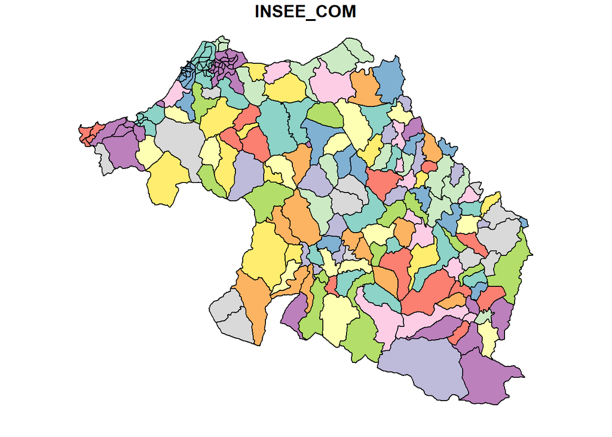

```r
plot(IRISBasque["INSEE_COM"])
```

### 1.4.2 Calculer et cartographier le prix moyen au m² par IRIS

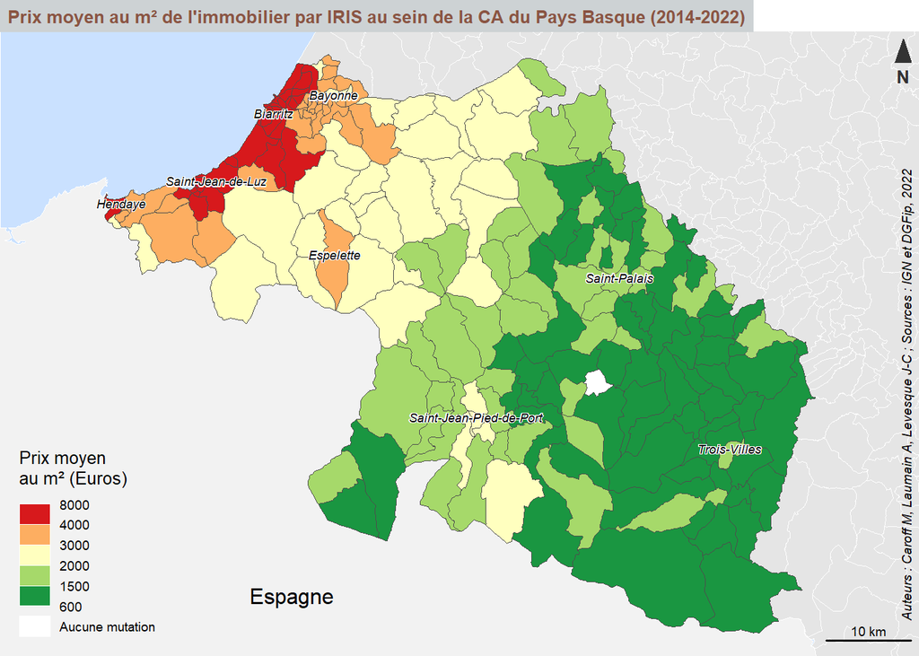

```r
# Calcul du prix moyen au m² par IRIS
IRISDVF <- IRISBasque %>% st_join(MutationsBasques) %>% group_by(CODE_IRIS) %>% summarise(Prixm2 = mean(prixm2))

# Sélection des communes dont le nom sera affiché sur la carte
liste_noms_Pays_Basque <- c("Biarritz", "Bayonne", "Saint-Jean-de-Luz", "Hendaye", "Espelette", "Saint-Palais", "Saint-Jean-Pied-de-Port", "Trois-Villes")
Selection_Communes_Pays_Basque <- Com_EPCI[which(Com_EPCI$com_name %in% liste_noms_Pays_Basque),]

# Sélection des communes dont le nom sera affiché sur le carton et l'atlas final
liste_noms_Pays_Basque_Carton <- c("Biarritz", "Bayonne", "Anglet")
Selection_Communes_Pays_Basque_Carton <- Com_EPCI[which(Com_EPCI$com_name %in% liste_noms_Pays_Basque_Carton),]

# Paramétrage des marges de la fenêtre pour maximiser l'emprise de la carte
par(mar = c(0, 0, 1.2, 0))

# Affichage des communes de notre EPCI et celles aux alentours en arrière-plan et centrage de la carte sur le Pays Basque
plot(st_geometry(Communes_Reg), lwd = 0.1, col = "grey90", border = "white", bg = "lightsteelblue1", xlim = c(st_bbox(IRISBasque)[1], st_bbox(IRISBasque)[3]), ylim = c(st_bbox(IRISBasque)[2], st_bbox(IRISBasque)[4]))

#Affichage de l'Espagne
plot(st_geometry(Espagne), lwd = 0.1, col = "grey95", border = "white", add = T)

choroLayer(
  x = IRISDVF,
  var = "Prixm2",
  breaks = c(600, 1500, 2000, 3000, 4000, 8000),
  col = c("#1a9641", "#a6d96a", "#ffffbf", "#fdae61", "#d7191c"),
  add=T,
  border = "grey30",
  lwd = 0.3,
  legend.nodata = "Aucune mutation",
  legend.border = "white",
  legend.title.txt = "Prix moyen \nau m² (Euros)",
  legend.title.cex = 0.8)

layoutLayer(title = "Prix moyen au m² de l'immobilier par IRIS au sein de la CA du Pays Basque (2014-2022)", source = "        Auteurs : Caroff M, Laumain A, Levesque J-C ; Sources : IGN et DGFip, 2022",
            north = TRUE, horiz = FALSE, tabtitle = TRUE,
            frame = FALSE, col = "#cdd2d4", coltitle = "#8A5543")

# Ajouter les étiquettes des communes selectionnées plus haut
labelLayer(Selection_Communes_Pays_Basque, txt = "com_name", halo = TRUE, bg = "white", r = 0.05, cex = 0.55, pos = 3, font = 3, offset = 0, overlap = TRUE)

# Habillage
mtext(text = "Espagne",
      side = 3, line = -22, adj = 0.3, cex = 1, col = "#000004FF")
```

### 1.4.3 Calculer et cartographier le nombre de mutations par IRIS

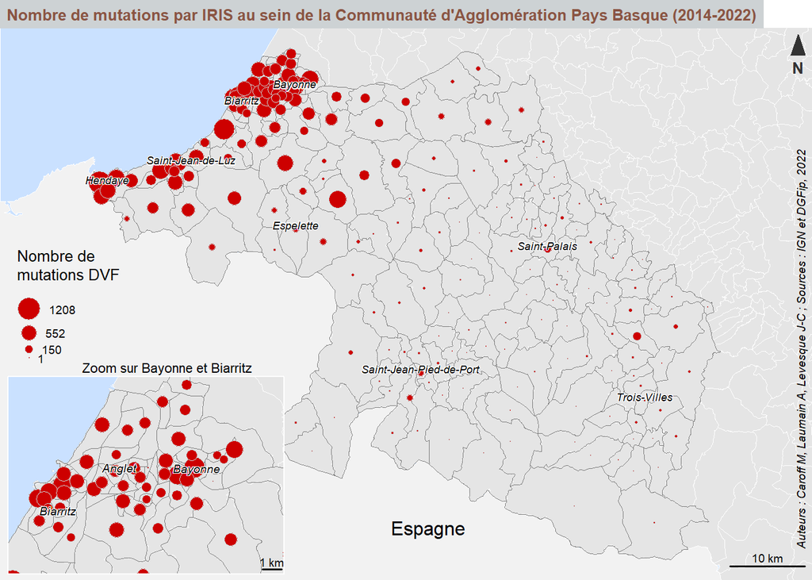

```r
# Calcul du nombre de mutations par IRIS
IRISDVF <- IRISDVF %>% mutate(Nbmutations = lengths(st_intersects(IRISDVF, MutationsBasques)))
IRISDVF <- IRISDVF %>% na.omit() # pour supprimer les valeurs manquantes

# Paramétrage des marges de la fenêtre pour maximiser l'emprise de la carte
par(mar = c(0, 0, 1.2, 0))

# Affichage des communes de notre EPCI et celles aux alentours en arrière-plan et centrage de la carte sur le Pays Basque
plot(st_geometry(Communes_Reg), lwd = 0.1, col = "grey90", border = "white", bg = "lightsteelblue1", xlim = c(st_bbox(IRISBasque)[1], st_bbox(IRISBasque)[3]), ylim = c(st_bbox(IRISBasque)[2], st_bbox(IRISBasque)[4]))

#Affichage de l'Espagne
plot(st_geometry(Espagne), lwd = 0.1, col = "grey95", border = "white", add = T)

# Affichage des IRIS
plot(st_geometry(IRISBasque), # appel du jeu de données
     border = "grey50", # couleur de la bordure des IRIS
     add = TRUE,
     lwd = 0.2)


# Affichage des symboles proportionnels (nombre de mutations)
propSymbolsLayer(x = IRISDVF, # appel du jeu de données
                 var = "Nbmutations", # appel de la variable à cartographier
                 col = "red3", # couleur cercles
                 border = "grey80",  # couleur bordure cercle
                 lwd = 0.01,
                 inches = 0.10, # Taille des cercles
                 add = TRUE,
                 legend.pos = "n",
                 )

layoutLayer(title = "Nombre de mutations par IRIS au sein de la Communauté d'Agglomération Pays Basque (2014-2022)", source = "        Auteurs : Caroff M, Laumain A, Levesque J-C ; Sources : IGN et DGFip, 2022", north = TRUE, horiz = FALSE, tabtitle = TRUE, frame = FALSE, col = "#cdd2d4", coltitle = "#8A5543")

legendCirclesSymbols(
  pos = "left",
  title.txt = "Nombre de \nmutations DVF",
  title.cex = 0.8,
  cex = 1,
  border = "grey80",
  lwd = 0.01,
  values.cex = 0.6,
  var = c(min(IRISDVF$Nbmutations), max(IRISDVF$Nbmutations)),
  inches = 0.10,
  col = "red3",
  frame = FALSE,
  values.rnd = 0,
  style = "e"
)

# Ajouter les étiquettes des communes selectionnées plus haut
labelLayer(Selection_Communes_Pays_Basque, txt = "com_name", halo = TRUE, bg = "white", r = 0.05, cex = 0.55, pos = 3, font = 3, offset = 0, overlap = TRUE)


# Ajout d'un carton focalisé sur Bayonne et Biarritz
par(fig = c(0.01,0.35,0.01,0.35),
    mar = c(0,0,0,0),
    new = TRUE)

# Centrage de la carte sur Bayonne et Biarritz
plot(st_geometry(Com_EPCI[Com_EPCI$com_code %in% c("64024", "64102", "64122"),]),
     border = "grey80", bg = "lightsteelblue1")

# Affichage des communes de notre EPCI et celles aux alentours en arrière-plan et centrage de la carte sur le Pays Basque
plot(st_geometry(Communes_Reg), lwd = 0.1, col = "grey90", border = "white", add = T)

# Affichage des IRIS
plot(st_geometry(IRISBasque), # appel du jeu de données
     border = "grey50", # couleur de la bordure des IRIS
     add = TRUE,
     lwd = 0.2)

# Affichage des symboles proportionnels (nombre de mutations)
propSymbolsLayer(x = IRISDVF, # appel du jeu de données
                 var = "Nbmutations", # appel de la variable à cartographier
                 col = "red3", # couleur cercles
                 border = "grey80",  # couleur bordure cercle
                 lwd = 0.01,
                 inches = 0.10, # Taille des cercles
                 add = TRUE,
                 legend.pos = "n",
                 )


# Affichage de l'échelle et d'un sous-titre
layoutLayer(title = "", source = "", north = F, horiz = FALSE,
            tabtitle = F, frame = FALSE)

mtext(text = "Zoom sur Bayonne et Biarritz",
      side = 3, line = 0, adj = 0.7, cex = 0.7, col = "#000004FF")

# Ajouter les étiquettes des communes selectionnées plus haut
labelLayer(Selection_Communes_Pays_Basque_Carton, txt = "com_name", halo = TRUE, bg = "white", r = 0.05, cex = 0.6, pos = 3, font = 3, offset = 0, overlap = TRUE)

# Ajout d'un cadre autour de la figure
box(col = "white")

# Habillage
mtext(text = "Espagne",
      side = 3, line = -7, adj = 1.9, cex = 1, col = "#000004FF")
```

## 1.5 Exploration des prix et des volumes à l’échelon des sections cadastrales

### 1.5.1 Importer la couche des sections cadastrales (DGFip)

```r
Sections <- st_read("sections_ok.shp")
```

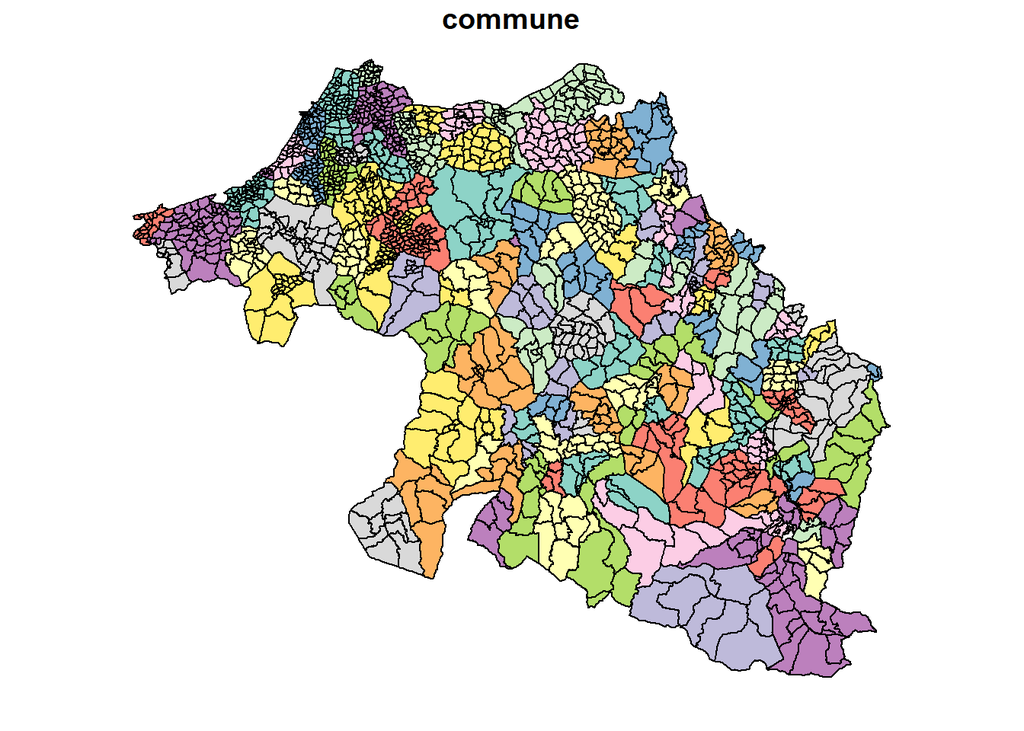

```r
Sections$id <- as.character(Sections$id)
SectionsEPCI <- Sections %>% filter(commune %in% listeCodeComBasque) %>% mutate(codesection = id)
plot(SectionsEPCI["commune"])
```

### 1.5.2 Calculer et cartographier le prix moyen au m² par section cadastrale

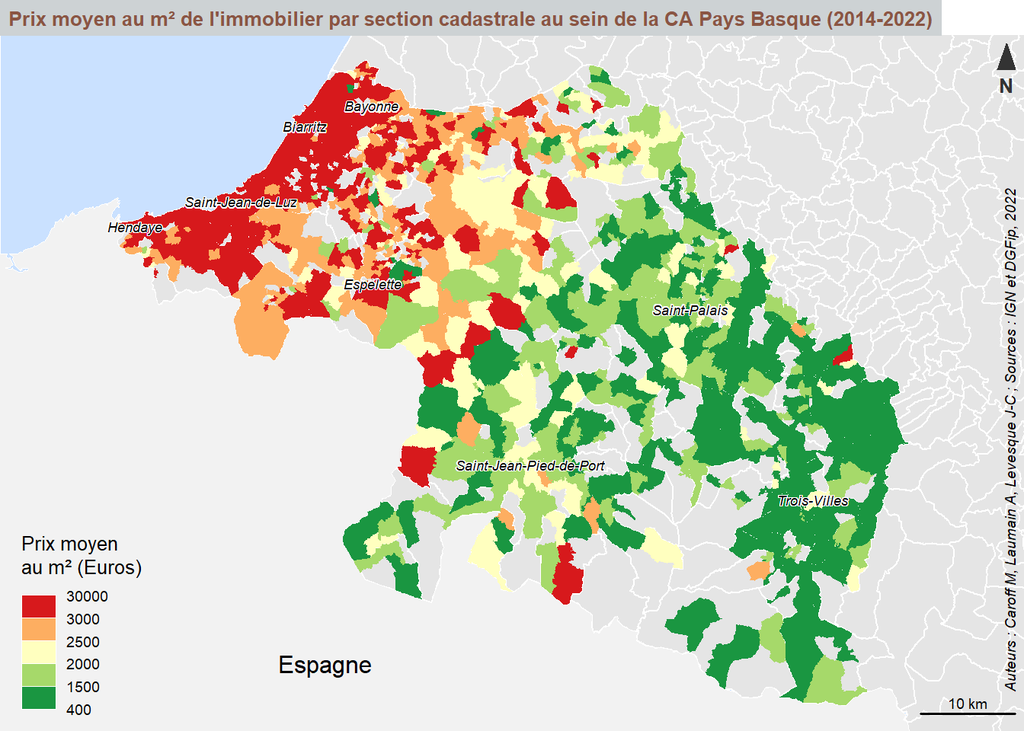

```r
# Calcul du prix moyen au m² par section
SectionsDVF <- SectionsEPCI %>% st_join(MutationsBasques) %>% group_by(codesection) %>% summarise(Prixm2 = mean(prixm2))
SectionsDVF <- SectionsDVF %>% na.omit() # pour supprimer les valeurs manquantes

# Paramétrage des marges de la fenêtre pour maximiser l'emprise de la carte
par(mar = c(0, 0, 1.2, 0))

# Affichage des communes de notre EPCI et celles aux alentours en arrière-plan et centrage de la carte sur le Pays Basque
plot(st_geometry(Communes_Reg), lwd = 1, col = "grey90", border = "white", bg = "lightsteelblue1", xlim = c(st_bbox(IRISBasque)[1], st_bbox(IRISBasque)[3]), ylim = c(st_bbox(IRISBasque)[2], st_bbox(IRISBasque)[4]))

#Affichage de l'Espagne
plot(st_geometry(Espagne), lwd = 0.1, col = "grey95", border = "white", add = T)

# Affichage de la carte des prix au m² par section cadastrale
choroLayer(
  x = SectionsDVF,
  var = "Prixm2",
  breaks = c(400, 1500, 2000, 2500, 3000, 30000),
  col = c("#1a9641", "#a6d96a", "#ffffbf", "#fdae61", "#d7191c"),
  add = TRUE,
  border = NA,
  legend.nodata = "Aucune mutation",
  legend.border = "white",
  legend.title.txt = "Prix moyen \nau m² (Euros)",
  legend.title.cex = 0.8)


layoutLayer(title = "Prix moyen au m² de l'immobilier par section cadastrale au sein de la CA Pays Basque (2014-2022)", source ="        Auteurs : Caroff M, Laumain A, Levesque J-C ; Sources : IGN et DGFip, 2022",
            north = TRUE, horiz = FALSE, tabtitle = TRUE,
            frame = FALSE, col = "#cdd2d4", coltitle = "#8A5543")

# Ajouter les étiquettes des communes selectionnées plus haut
labelLayer(Selection_Communes_Pays_Basque, txt = "com_name", halo = TRUE, bg = "white", r = 0.05, cex = 0.55, pos = 3, font = 3, offset = 0, overlap = TRUE)

mtext(text = "Espagne",
      side = 3, line = -22, adj = 0.3, cex = 1, col = "#000004FF")
```

### 1.5.3 Calculer et cartographier le nombre de mutations par section cadastrale

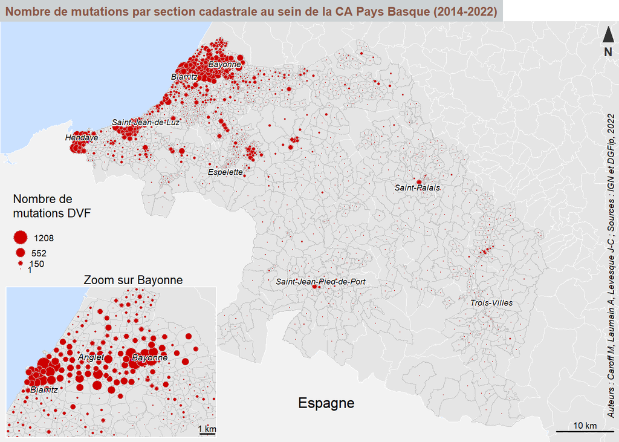

```r
# Calcul du nombre de mutations par section
SectionsDVF <- SectionsDVF %>% mutate(Nbmutations = lengths(st_intersects(SectionsDVF, MutationsBasques)))

# Paramétrage des marges de la fenêtre pour maximiser l'emprise de la carte
par(mar = c(0, 0, 1.2, 0))

# Affichage des communes de notre EPCI et celles aux alentours en arrière-plan et centrage de la carte sur le Pays Basque
plot(st_geometry(Communes_Reg), lwd = 0.1, col = "grey90", border = "white", bg = "lightsteelblue1", xlim = c(st_bbox(IRISBasque)[1], st_bbox(IRISBasque)[3]), ylim = c(st_bbox(IRISBasque)[2], st_bbox(IRISBasque)[4]))

#Affichage de l'Espagne
plot(st_geometry(Espagne), lwd = 0.1, col = "grey95", border = "white", add = T)

# Affichage des sections cadastrales
plot(st_geometry(SectionsDVF), # appel du jeu de données
     border = "grey75", # couleur de la bordure
     add = TRUE,
     lwd = 0.05)

# Affichage des symboles proportionnels (nombre de mutations)
propSymbolsLayer(x = SectionsDVF, # appel du jeu de données
                 var = "Nbmutations", # appel de la variable à cartographier
                 col = "red3", # couleur cercles
                 border = "grey80",  # couleur bordure cercle
                 lwd = 0.01,
                 inches = 0.08, # Taille des cercles
                 add = TRUE,
                 legend.pos = "n",
                 )

layoutLayer(title = "Nombre de mutations par section cadastrale au sein de la CA Pays Basque (2014-2022)", source = "        Auteurs : Caroff M, Laumain A, Levesque J-C ; Sources : IGN et DGFip, 2022", north = TRUE, horiz = FALSE, tabtitle = TRUE, frame = FALSE, col = "#cdd2d4", coltitle = "#8A5543")



legendCirclesSymbols(
  pos = "left",
  title.txt = "Nombre de \nmutations DVF        ",
  title.cex = 0.8,
  cex = 1,
  border = "grey80",
  lwd = 0.01,
  values.cex = 0.6,
  var = c(min(IRISDVF$Nbmutations), max(IRISDVF$Nbmutations)),
  inches = 0.08,
  col = "red3",
  frame = FALSE,
  values.rnd = 0,
  style = "e"
)

# Ajouter les étiquettes des communes selectionnées plus haut
labelLayer(Selection_Communes_Pays_Basque, txt = "com_name", halo = TRUE, bg = "white", r = 0.05, cex = 0.55, pos = 3, font = 3, offset = 0, overlap = TRUE)


# Ajout d'un carton focalisé sur Bayonne et Biarritz
par(fig = c(0.01,0.35,0.01,0.35),
    mar = c(0,0,0,0),
    new = TRUE)

# Centrage de la carte sur Bayonne et Biarritz
plot(st_geometry(Com_EPCI[Com_EPCI$com_code %in% c("64024", "64102", "64122"),]),
     border = "grey80", bg = "lightsteelblue1")

# Affichage des communes de notre EPCI et celles aux alentours en arrière-plan et centrage de la carte sur le Pays Basque
plot(st_geometry(Communes_Reg), lwd = 0.1, col = "grey90", border = "white", add = T)

# Affichage des sections cadastrales
plot(st_geometry(SectionsDVF), # appel du jeu de données
     border = "grey75", # couleur de la bordure
     add = TRUE,
     lwd = 0.05)

# Affichage des symboles proportionnels (nombre de mutations)
propSymbolsLayer(x = SectionsDVF, # appel du jeu de données
                 var = "Nbmutations", # appel de la variable à cartographier
                 col = "red3", # couleur cercles
                 border = "grey80",  # couleur bordure cercle
                 lwd = 0.01,
                 inches = 0.08, # Taille des cercles
                 add = TRUE,
                 legend.pos = "n",
)

# Affichage de l'échelle et d'un sous-titre
layoutLayer(title = "", source = "", north = F, horiz = FALSE,
            tabtitle = F, frame = FALSE)

# Affichage des noms de communes
labelLayer(Selection_Communes_Pays_Basque_Carton, txt = "com_name", halo = TRUE, bg = "white", r = 0.05, cex = 0.6, pos = 3, font = 3, offset = 0, overlap = TRUE)

mtext(text = "Zoom sur Bayonne",
      side = 3, line = 0, adj = 0.7, cex = 0.8, col = "#000004FF")


# Ajout un cadre autour de la figure
box(col = "white")

# Habillage
mtext(text = "Espagne",
      side = 3, line = -7, adj = 1.9, cex = 1, col = "#000004FF")
```

## 1.6 Lissage spatial (échelle de l’EPCI)

### 1.6.1 Lissage spatial des prix de l’immobilier au m² calculés à partir des valeurs agrégées par IRIS

Avant de commencer les traitements sur le lissage spatial, il faut anticiper la prise en compte de l’effet de bord. Pour cela, nous avons fait le choix d élargir notre zone de traitement. Les communes frontalières à notre EPCI seront prisent en compte dans le lissage, puis un masque sera appliqué pour les cacher. Ainsi, les mutations situées à proximité des frontières seront intégrées à notre lissage.

On commence par faire une liste de ces communes frontalières et on applique les mêmes calculs faits précédement à notre EPCI.

```r
#Liste des communes frontalières à celles de notre EPCI
listeCodeComFronta <- list(40273, 64004, 40120, 64215, 40212, 64040, 64412, 64458, 64310, 40312, 40271, 64241, 64025, 64291, 64334, 64029, 64253, 40306, 64494, 64039, 64480, 64481, 64083, 40231, 40268, 64251, 64529, 64217, 40206, 40251, 64186, 64178, 64244)
Comm_Basque_Elargie <- IRIS_France %>%  filter(INSEE_COM %in% listeCodeComBasque |INSEE_COM %in% listeCodeComFronta)

DVF_Elargie <- Comm_Basque_Elargie %>% st_join(Mutations_Aquit) %>% group_by(CODE_IRIS) %>% summarise(Prixm2 = mean(prixm2))

# Calcul du nombre de mutations
DVF_Elargie <- DVF_Elargie %>% mutate(Nbmutations = lengths(st_intersects(DVF_Elargie, Mutations_Aquit)))
DVF_Elargie <- DVF_Elargie %>% na.omit() # pour supprimer les valeurs manquantes
```

#### 1.6.1.1 Calcul des distances au plus proche voisin et de l’auto-corrélation spatiale des prix au m²

```r
# pour convertir la couche des IRIS au format spatial object (format requis par le package geoR)
IRISDVF.sp <- as(DVF_Elargie, "Spatial")

# pour calculer les centroïdes des IRIS (indispensable pour le calcul sur les plus proches voisins)
IRISDVF.Centroids <- gCentroid(IRISDVF.sp,byid=TRUE)

# pour récupérer les données initiales des IRIS sur les centroïdes
IRISDVF.Centroids <- SpatialPointsDataFrame(IRISDVF.Centroids, IRISDVF.sp@data)

# Calcul sur les plus proches voisins
listPPV <- knearneigh(IRISDVF.Centroids@coords, k = 1) # pour connaître le plus proche voisin de chaque communes
PPV <- knn2nb(listPPV, row.names = IRISDVF.Centroids$code_iris) # pour convertir l'objet knn en objet nb
distPPV <- nbdists(PPV, IRISDVF.Centroids@coords) # pour connaître la distance entre plus proches voisins
print(as.data.frame(t(as.matrix(summary(unlist(distPPV))))))
```

```
##       Min.  1st Qu.   Median     Mean  3rd Qu.     Max.
## 1 308.7489 1417.873 2455.432 2455.476 3318.053 7415.731
```

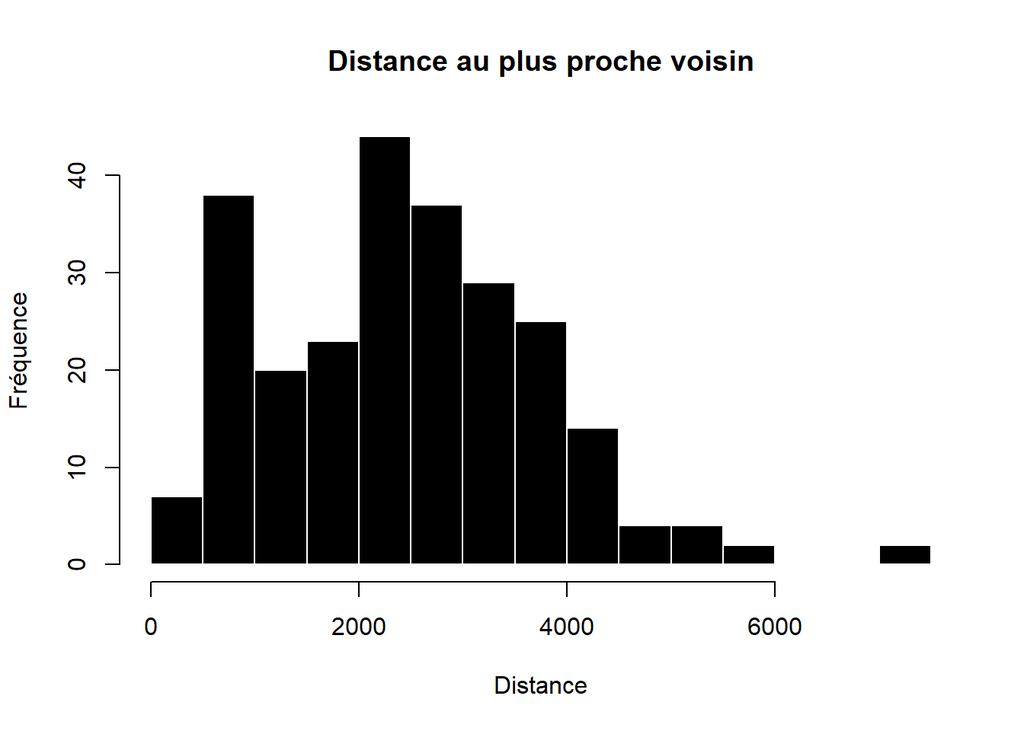

```r
hist(unlist(distPPV), breaks = 20,
     main = "Distance au plus proche voisin",
     col = "black", border = "white", xlab = "Distance", ylab = "Fréquence")
```

```r
# pour convertir les IRIS en objet nb
IRIS.nb <- poly2nb(pl = DVF_Elargie,
                 row.names = DVF_Elargie$code_iris,
                 snap = 50,
                 queen = TRUE)
#calcul du test de Moran
moran.test(DVF_Elargie$Prixm2, listw = nb2listw(IRIS.nb))
```

```
##
##  Moran I test under randomisation
##
## data:  DVF_Elargie$Prixm2
## weights: nb2listw(IRIS.nb)
##
## Moran I statistic standard deviate = 24.096, p-value < 2.2e-16
## alternative hypothesis: greater
## sample estimates:
## Moran I statistic       Expectation          Variance
##       0.925991658      -0.004032258       0.001489704
```

#### 1.6.1.2 Carte lissée des prix de l’immobilier au m² calculés à partir des valeurs agrégées par IRIS sur l’ensemble de l’EPCI

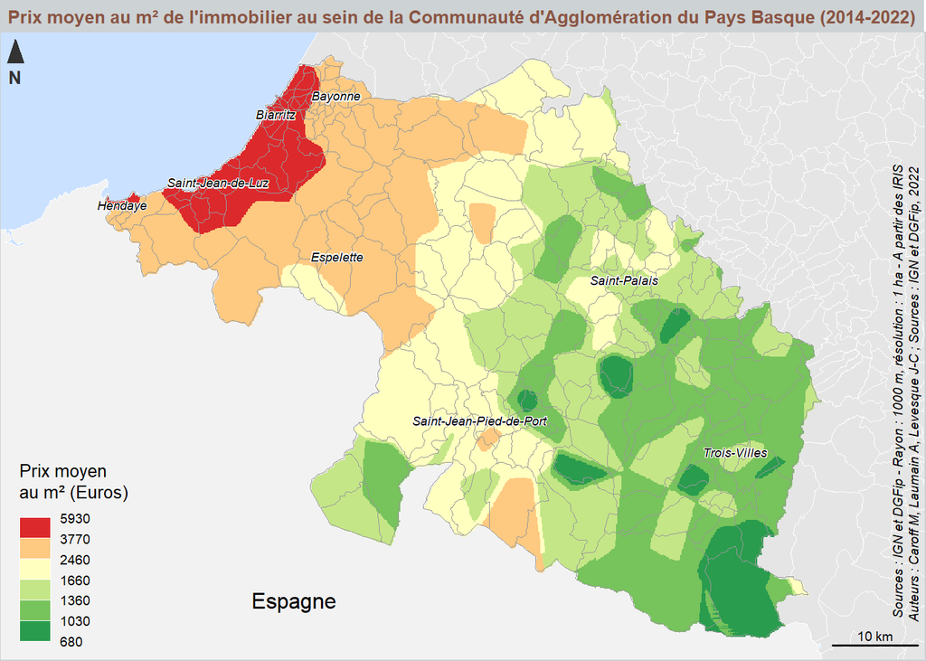

```r
# pour définir le contour de notre EPCI comme emprise pour le lissage (sinon le lissage est calculé sur une fenêtre rectangulaire)
EmpriseBasque <- as.owin(as(Comm_Basque_Elargie, "Spatial"))

# pour récupérer les coordonnées du centroïde des IRIS
pts <- st_coordinates(st_point_on_surface(st_geometry(DVF_Elargie)))

# pour créer un objet ppp (format spatstat) et y intégrer dedans l'emprise et les valeurs à lisser (prix au m²)
IRISDVF.ppp <- ppp(pts[,1], pts[,2], window = EmpriseBasque, marks = DVF_Elargie$Prixm2)

# pour calculer la surface lissée (rayon lissage : 1 km et résolution spatiale de l'image : 1 ha)
cartelissee <- Smooth(IRISDVF.ppp, sigma = 1000, weights = IRISDVF.ppp$marks, eps=100)

# Conversion de la surface lissée au format raster
cartelissee.raster <- raster(cartelissee, crs = st_crs(DVF_Elargie)[[2]])

# découpage de la surface lissée sur l'emprise de mon EPCI
cartelissee.raster <- mask(cartelissee.raster, IRISBasque)

# Paramétrage des marges de la fenêtre pour maximiser l'emprise de la carte
par(mar = c(0, 0, 1.2, 0))

# pour afficher la surface lissée et définir l'habillage
# Calcul des seuils
bks <- unique(getBreaks(values(cartelissee.raster), method = "q6"))

# Création d'une palette de couleurs (double gradation harmonique)
cols <- c("#2a9c4e", "#77c35c", "#c4e687", "#ffffc0", "#fec981", "#dc292c")

# Affichage des communes de notre EPCI et celles aux alentours en arrière-plan et centrage de la carte sur le Pays Basque
plot(st_geometry(Communes_Reg), lwd = 0.1, col = "grey90", border = "white", bg = "lightsteelblue1", xlim = c(st_bbox(IRISBasque)[1], st_bbox(IRISBasque)[3]), ylim = c(st_bbox(IRISBasque)[2], st_bbox(IRISBasque)[4]))

#Affichage de l'Espagne
plot(st_geometry(Espagne), lwd = 0.1, col = "grey95", border = "white", add = T)

# Affichage de la carte lissée et du contour des IRIS
plot(cartelissee.raster, breaks = bks, col=cols, add = T, legend=F)
plot(IRISDVF$geometry, border = "grey60", lwd = 0.03, add = T)

legendChoro(
  pos = "bottomleft",
  title.txt = "Prix moyen \nau m² (Euros)",
  title.cex = 0.8,
  breaks = bks,
  nodata = FALSE,
  values.rnd = -1,
  border = "white",
  col = cols
)

layoutLayer(title = "Prix moyen au m² de l'immobilier au sein de la Communauté d'Agglomération du Pays Basque (2014-2022)",
            author = "          Sources : IGN et DGFip - Rayon : 1000 m, résolution : 1 ha - A partir des IRIS \n         Auteurs : Caroff M, Laumain A, Levesque J-C ; Sources : IGN et DGFip, 2022",
            scale = 10, frame = TRUE, col = "#cdd2d4", coltitle = "#8A5543",
            north(pos = "topleft"), tabtitle=TRUE, horiz = FALSE)

# Ajouter les étiquettes des communes selectionnées plus haut
labelLayer(Selection_Communes_Pays_Basque, txt = "com_name", halo = TRUE, bg = "white", r = 0.05, cex = 0.55, pos = 3, font = 3, offset = 0, overlap = TRUE)

mtext(text = "Espagne",
      side = 3, line = -22, adj = 0.3, cex = 1, col = "#000004FF")
```

### 1.6.2 Lissage spatial du prix de l’immobilier au m² calculés à partir des valeurs agrégées par section cadastrale

On répète le même processus de prise en compte de l’effet de bord que pour les iris, à savoir, on élargie l’emprise de notre lissage puis on applique un masque.

```r
Sections_Elargie <- Sections %>%  filter(commune %in% listeCodeComBasque |commune %in% listeCodeComFronta) %>% mutate(codesection = id)

#Calcul du nombre de mutations
SectionsDVF_Elargie <- Sections_Elargie %>% st_join(Mutations_Aquit) %>% group_by(codesection) %>% summarise(Prixm2 = mean(prixm2))
SectionsDVF_Elargie <- SectionsDVF_Elargie %>% mutate(Nbmutations = lengths(st_intersects(SectionsDVF_Elargie, Mutations_Aquit)))

SectionsDVF_Elargie <- SectionsDVF_Elargie %>% na.omit() # pour supprimer les valeurs manquantes
```

#### 1.6.2.1 Calcul des distances au plus proche voisin et de l’auto-corrélation spatiale des prix au m²

```r
# pour convertir la couche des sections au format spatial object (format requis par le package geoR)
SectionsDVF.sp <- as(SectionsDVF_Elargie, "Spatial")

# pour calculer les centroïdes des sections (indispensable pour le calcul sur les plus proches voisins)
SectionsDVF.Centroids <- gCentroid(SectionsDVF.sp,byid=TRUE)

# pour récupérer les données initiales des sections sur les centroïdes
SectionsDVF.Centroids <- SpatialPointsDataFrame(SectionsDVF.Centroids, SectionsDVF.sp@data)

# Calcul sur les plus proches voisins
listPPV <- knearneigh(SectionsDVF.Centroids@coords, k = 1) # pour connaître le plus proche voisin de chaque Communes
PPV <- knn2nb(listPPV, row.names = SectionsDVF.Centroids$codesection) # pour convertir l'objet knn en objet nb
distPPV <- nbdists(PPV, SectionsDVF.Centroids@coords) # pour connaître la distance entre plus proches voisins
print(as.data.frame(t(as.matrix(summary(unlist(distPPV))))))
```

[output not shown]

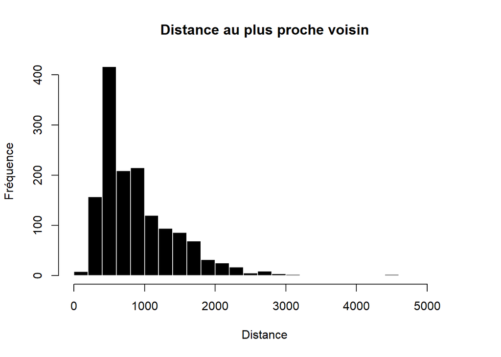

```r
hist(unlist(distPPV), breaks = 20,
     main = "Distance au plus proche voisin",
     col = "black", border = "white", xlab = "Distance", ylab = "Fréquence")
```

```r
# pour convertir les sections en objet nb
Section.nb <- poly2nb(pl = SectionsDVF_Elargie,
                 row.names = SectionsDVF_Elargie$codesection,
                 snap = 50,
                 queen = TRUE)

#calcul du test de Moran
#moran.test(SectionsDVF_Elargie$Prixm2, listw = nb2listw(Section.nb))

#En raison d'erreurs de topologie de la couche des sections cadastrales, le calcul de l'indice de Moran est impossible.
```

#### 1.6.2.2 Carte lissée des prix de l’immobilier au m² calculés à partir des valeurs agrégées par section cadastrale sur l’ensemble de notre EPCI

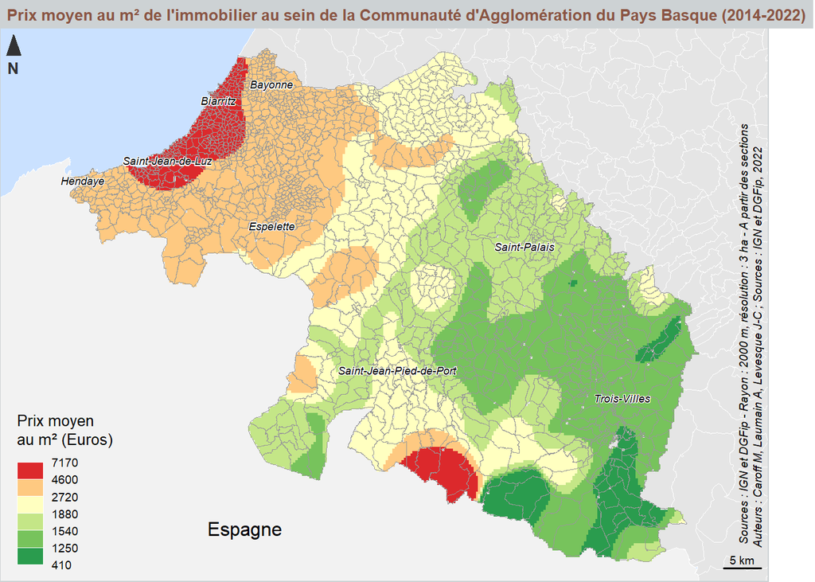

```r
# pour définir le contour de l'EPCI comme emprise pour le lissage (sinon le lissage est calculé sur une fenêtre rectangulaire)
EmpriseBasque <- as.owin(as(Sections_Elargie, "Spatial"))

# pour récupérer les coordonnées du centroïde des sections
pts <- st_coordinates(st_point_on_surface(st_geometry(SectionsDVF_Elargie)))

# pour créer un objet ppp (format spatstat) et y intégrer dedans l'emprise et les valeurs à lisser (prix au m²)
Sections.ppp <- ppp(pts[,1], pts[,2], window = EmpriseBasque, marks = SectionsDVF_Elargie$Prixm2)

# pour calculer la surface lissée (rayon lissage : 2 km et résolution spatiale de l'image : 3 ha)
cartelissee <- Smooth(Sections.ppp, sigma = 2000, weights = Sections.ppp$marks, eps=300)
# Conversion de la surface lissée au format raster
cartelissee.raster <- raster(cartelissee, crs = st_crs(SectionsDVF_Elargie)[[2]])
# découpage de la surface lissée sur l'emprise de mon EPCI
cartelissee.raster <- mask(cartelissee.raster, SectionsEPCI)

# Paramétrage des marges de la fenêtre pour maximiser l'emprise de la carte
par(mar = c(0, 0, 1.2, 2))

# pour afficher la surface lissée et définir l'habillage
# Calcul des seuils
bks <- unique(getBreaks(values(cartelissee.raster), method = "q6"))

# Création d'une palette de couleurs (double gradation harmonique)
cols <- c("#2a9c4e", "#77c35c", "#c4e687", "#ffffc0", "#fec981", "#dc292c")

# Affichage des communes de notre EPCI et celles aux alentours en arrière-plan et centrage de la carte sur le Pays Basque
plot(st_geometry(Communes_Reg), lwd = 0.1, col = "grey90", border = "white", bg = "lightsteelblue1", xlim = c(st_bbox(SectionsEPCI)[1], st_bbox(SectionsEPCI)[3]), ylim = c(st_bbox(SectionsEPCI)[2], st_bbox(SectionsEPCI)[4]))

#Affichage de l'Espagne
plot(st_geometry(Espagne), lwd = 0.1, col = "grey95", border = "white", add = T)

# Affichage de la carte lissée et du contour des sections
plot(cartelissee.raster, breaks = bks, col=cols, add = T, legend=F)
plot(SectionsEPCI$geometry, border = "grey60", lwd = 0.01, add = T)

legendChoro(
  pos = "bottomleft",
  title.txt = "Prix moyen \nau m² (Euros)",
  title.cex = 0.8,
  breaks = bks,
  nodata = FALSE,
  values.rnd = -1,
  border = "white",
  col = cols
)

layoutLayer(title = "Prix moyen au m² de l'immobilier au sein de la Communauté d'Agglomération du Pays Basque (2014-2022)",
            author = "          Sources : IGN et DGFip - Rayon : 2000 m, résolution : 3 ha - A partir des sections \n         Auteurs : Caroff M, Laumain A, Levesque J-C ; Sources : IGN et DGFip, 2022",
            scale = 5, frame = TRUE, col = "#cdd2d4", coltitle = "#8A5543",
            north(pos = "topleft"), tabtitle=TRUE, horiz = FALSE)

# Ajouter les étiquettes des communes sélectionnées plus haut
labelLayer(Selection_Communes_Pays_Basque, txt = "com_name", halo = TRUE, bg = "white", r = 0.05, cex = 0.55, pos = 3, font = 3, offset = 0, overlap = TRUE)

mtext(text = "Espagne",
      side = 3, line = -22, adj = 0.3, cex = 1, col = "#000004FF")
```

### 1.6.3 Lissage spatial des prix de l’immobilier au m² calculés directement à partir des mutations immobilières sur l’ensemble de l’EPCI

#### 1.6.3.1 Calcul de la distance au plus proche voisin et de l’auto-corrélation spatiale des prix au m²

```r
# pour convertir les mutations en objet spatial (format requis par le package geoR)
MutationsBasque.sp <- as(MutationsBasques, "Spatial")

# Calcul sur les plus proches voisins
listPPV <- knearneigh(MutationsBasque.sp@coords, k = 1) # pour connaître le plus proche voisin de chaque mutation
PPV <- knn2nb(listPPV, row.names = MutationsBasque.sp$id) # pour convertir l'objet knn en objet nb
distPPV <- nbdists(PPV, MutationsBasque.sp@coords) # pour connaître la distance entre plus proches voisins
print(as.data.frame(t(as.matrix(summary(unlist(distPPV))))))
```

```
##   Min. 1st Qu. Median    Mean  3rd Qu.     Max.
## 1    0       0      0 28.0985 16.49738 6707.369
```

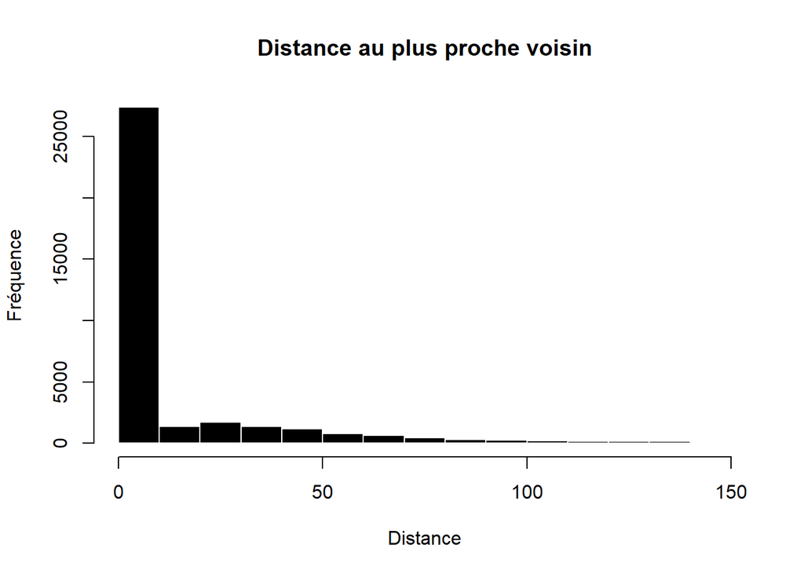

```r
hist(unlist(distPPV), nclass = 600,
     main = "Distance au plus proche voisin",
     col = "black", border = "white", xlab = "Distance", ylab = "Fréquence", xlim = c(0,150))
```

```r
#calcul du test de Moran
moran.test(MutationsBasque.sp$prixm2, listw = nb2listw(PPV))
```

```
##
##  Moran I test under randomisation
##
## data:  MutationsBasque.sp$prixm2
## weights: nb2listw(PPV)
##
## Moran I statistic standard deviate = 90.267, p-value < 2.2e-16
## alternative hypothesis: greater
## sample estimates:
## Moran I statistic       Expectation          Variance
##      5.483585e-01     -2.653505e-05      3.690762e-05
```